# **Youthful Eyes on OTT: A Global Content Production Analysis**

### *Submitted By: Puneeth Virushabadas [pv6678] and Urjani Chakravarti [uc845]*

### *Course Name: Data Wrangling INF 385T*

### Project workspace link - https://app.datacamp.com/workspace/w/c0891cf5-1971-4159-b0aa-fdf8c5bb1e4d/edit

## Project Description

In this project, our primary aim is to investigate the potential correlation between the proportion of young people in a country and the quantity of content generated on Over-The-Top (OTT) platforms. Over the top platforms are online platforms which provides content release services and provide contents to the consumer over the internet. It gets its name Over the top (OTT) as the contents are released over the top of the internet services. Here, We wanted to differentiate between longer formats, such as TV shows, and shorter formats like movies. Our study seeks to determine whether the presence of a youthful demographic in a country has a discernible impact on the overall volume of content produced on OTT platforms.

## Analysis Roadmap:

1. To uncover insights into the connection between OTT platforms and the percentage of the young population.
2. To investigate potential variations in these relationships among different countries.
3. To assess whether these observed patterns influence production companies in adapting their content strategies.
4. To pinpoint specific time periods during which particular OTT platforms intentionally increased their content production in response to shifts in the age demographic.

## Challenges:

The primary hurdle in this project lies in avoiding duplicate titles within content details. For example, if a specific content is released on multiple OTT platforms, our goal is to recognize it as a singular piece of content. To address this, we've integrated a Fuzzy Logic and Sentence Transformer designed to manage the movie titles utilising the advantages of both Sentence Transformer and Fuzzy Logic.

## Datasources

**Project CSV Files and Sources:** This project utilizes 6 CSV files that are sourced from 3 different sources. The sources are: kaggle.com, data.oecd, and iban.com

The CSV files along with their description and sources are down below:

**CSV Source:** https://www.kaggle.com/datasets/shivamb/netflix-shows

**Description of netflix_titles_titles.csv:** The following CSV file contains information about the various content that was aired on Netflix. The file was already available as a CSV, hence we only had to download it. • show_id: Unique id of each show or movie • type: Type of content - 'Movie' or 'TV Show' • title: Name/title of each content • director: Name of the content director • cast: Names of cast members • country: Country where the content was aired • date_added: Date when the content was added to the OTT platform • release_year: Date when the content was released • rating: Rating of the content, for example, 13+, TV-Y7, R, etc • duration: Length of the content • listed_in: Genre of the content • description: Description of the content

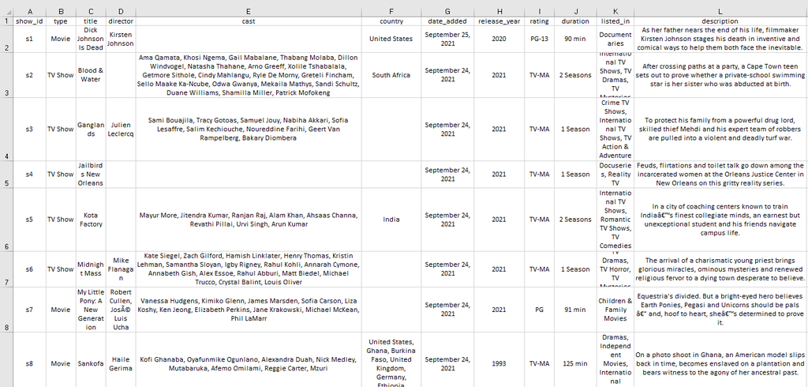

```python
from IPython.display import Image # Using this library to support HTML embed
Image(filename="Project Netflix.png")
```

**CSV Source:** https://www.kaggle.com/datasets/shivamb/amazon-prime-movies-and-tv-shows

**Description of amazon_prime_titles.csv:** The following CSV file contains information about the various content that was aired on Amazon Prime. The file was already available as a CSV, hence we only had to download it. • show_id: Unique id of each show or movie • type: Type of content - 'Movie' or 'TV Show' • title: Name/title of each content • director: Name of the content director • cast: Names of cast members • country: Country where the content was aired • date_added: Date when the content was added to the OTT platform • release_year: Date when the content was released • rating: Rating of the content, for example, 13+, TV-Y7, R, etc • duration: Length of the content • listed_in: Genre of the content • description: Description of the content

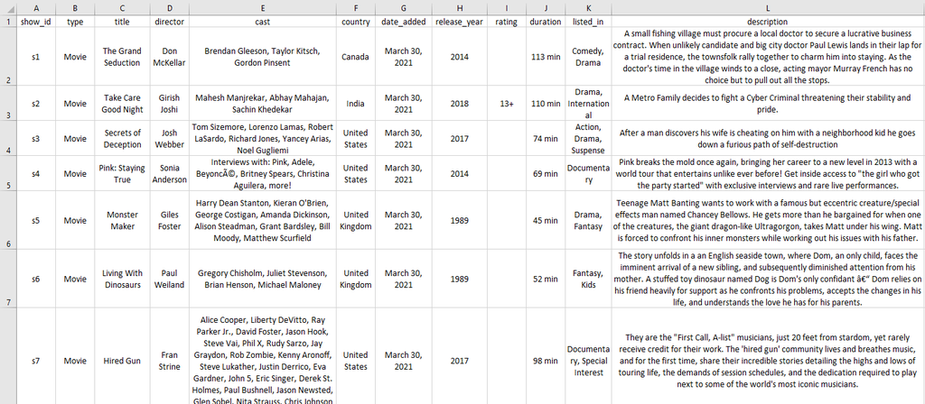

```python
Image(filename="Project Amazon.png")
```

**CSV Source:** https://www.kaggle.com/datasets/shivamb/hulu-movies-and-tv-shows

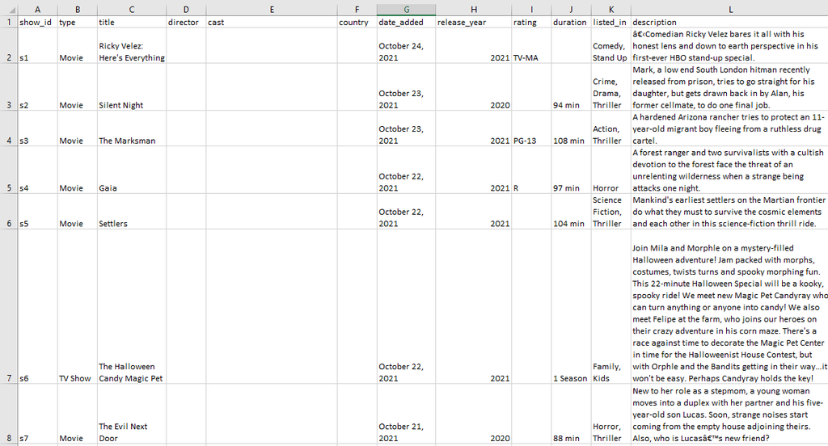

```python
Image(filename="Project Hulu.png")
```

**CSV Source:** https://www.kaggle.com/datasets/shivamb/disney-movies-and-tv-shows

**Description of disney_plus_titles.csv:** The following CSV file contains information about the various content that was aired on Disney Plus. The file was already available as a CSV, hence we only had to download it. • show_id: Unique id of each show or movie • type: Type of content - 'Movie' or 'TV Show' • title: Name/title of each content • director: Name of the content director • cast: Names of cast members • country: Country where the content was aired • date_added: Date when the content was added to the OTT platform • release_year: Date when the content was released • rating: Rating of the content, for example, 13+, TV-Y7, R, etc • duration: Length of the content • listed_in: Genre of the content • description: Description of the content

[figure not shown]

```python
Image(filename="Project Disney.png")
```

**CSV Source:** https://data.oecd.org/pop/young-population.htm

**Description of young_populations.csv** This file contains information about the young population (people aged less than 15 years) of a given location as a percentage of the total population of the country for specific years. The file was already available as a CSV, hence we only had to download it. • LOCATION: Country code or alternative name of the country. • INDICATOR: YNGPOP or young population. All fields in this column have the same value and can be removed. • SUBJECT: TOT or total. All fields in this column have the same value and can be removed. • MEASURE: PC_POP or percentage_population, indicating that the population is given as a percentage of the entire population of a country. • TIME: Year that this population percentage was measured. • Value: Young population as a percentage of the entire population of the country. • Flag Codes: Flag code of the country; this is null for all fields and can be removed.

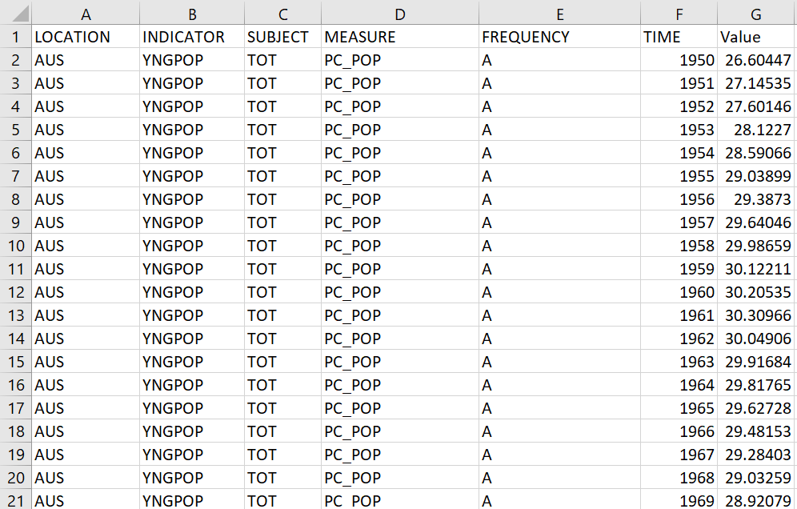

```python
Image(filename="Project Young Population.png")
```

**CSV Source:** https://www.iban.com/country-codes

**Description of country_names_codes.csv:** This file contains country names with their country codes. The first column is the name of the country and the other 2 columns represent the country codes in 2 different formats. The last column represents the numeric code.

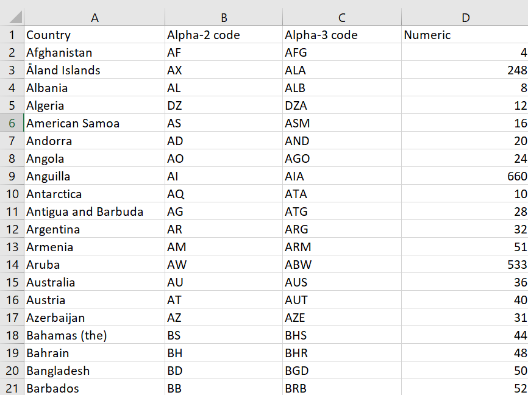

```python
Image(filename="Project Country Codes.png")
```

**Challenges:** All the CSV files were downloaded directly. We noticed that there were a few columns that had null values. Additionally, the dates were in different formats. We also noticed that there is a possibility that the titles are repeated in different datasets. Therefore, a fuzzy logic module was implemented to deal with this problem.

## Workflow

**Project Workflow Description:** Our project workflow incorporates the utilization of a fuzzy logic module to merge project titles, preventing repetition across various OTT platforms. Additionally, we employ a fuzzy matching module to address variations in country names. After cleansing the raw data, we employ Python queries to generate databases, which subsequently serve as the basis for deriving insights through SQL queries. The final step involves analyzing and visualizing results using analytics tools such as Power BI.

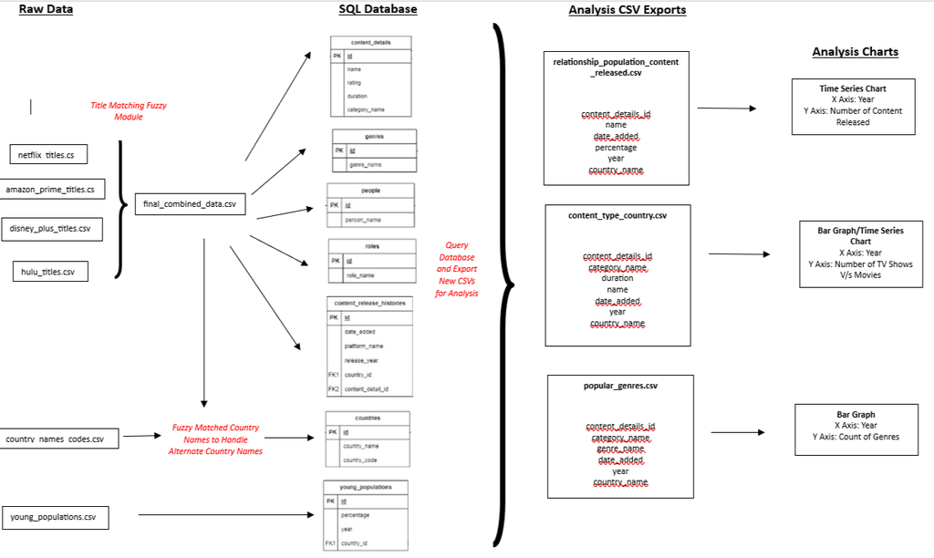

```python
Image(filename="Project Workflow.png")
```

## Handling Alternate Country Names:

To manage alternative country names, we've devised and implemented a fuzzy matching module. This module systematically iterates through each country in our OTT platform CSV files, comparing them with the entries in the "country_names_codes.csv" file. The countries that exhibit a fuzzy match are seamlessly added to the countries database, accompanied by their respective official ISO country codes (already available in the "country_names_codes.csv" file). This, in turn, can be utilized to match the official ISO country codes in the "young_populations.csv" file.

## Sentence Transformer and Fuzzy Match Algorithm

Sentence Transformers are models that transform text into fixed-size numerical representations (embeddings) suitable for various natural language processing tasks, including similarity calculations. These embeddings capture the semantic meaning of the text, allowing for effective comparison between sentences.

FuzzyWuzzy, on the other hand, is a library in Python that provides fuzzy string matching capabilities, allowing you to compare strings or sequences of text and determine their similarity based on various algorithms like Levenshtein distance, among others.

## Basic approach to using Sentence Transformers and FuzzyWuzzy together

Generate embeddings for your sentences using a Sentence Transformer model to represent the semantic meaning of the text.

1. Use the generated embeddings to compute the similarity between sentences. You can use cosine similarity or other distance metrics to compare the embeddings and quantify their similarity.
2. If needed, you can use FuzzyWuzzy to perform additional string matching or similarity calculations based on different algorithms provided by the library. However, keep in mind that FuzzyWuzzy primarily operates on the textual level and doesn't leverage semantic embeddings like Sentence Transformers do.
3. Combining these two approaches can provide a more comprehensive understanding of similarity by considering both the semantic meaning of text (captured by embeddings from Sentence Transformers) and the character-level or token-level similarities measured by FuzzyWuzzy.

When we ran without sentence transformer the time taken to execute and match titles was approximately around 7-10 hours and now this has been reduced to 2.5 hours after implementing Sentence Transformers and Fuzzy Wuzzy together.

## Concrete Diagram

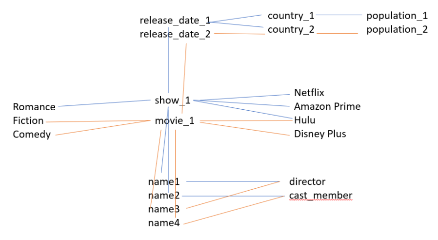

```python
Image(filename="Project Concrete Example.png")
```

**Relational Vocabulary:**

• A single content detail can be streamed on many OTT platforms. A single OTT platform can have many content details.

• A single content detail can have many genres. A single genre can be associated with many content details.

• A single content detail can have a single category (i.e., either a TV show or a movie). A single category can have many content details.

• A single content detail can have many people. A single person can be involved in many content details.

• A single content detail can be released multiple time, i.e., can have many content release histories. A single content release history is linked to a single content.

• A single person can have many roles. A single role can be fulfilled by many people.

• A single content detail can be released many times. A single release history is associated with only one content detail.

• A single country can have many content release histories. A single release history is linked to a single content detail.

• A single country can have many (fluctuating) populations. A single population (at a given moment) is linked to a single country.

## Conceptual ER Diagram

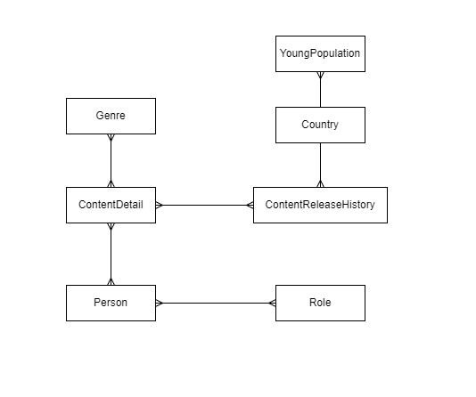

```python
Image(filename="CEROTTPlatforms.png")
```

## Physical ER diagram

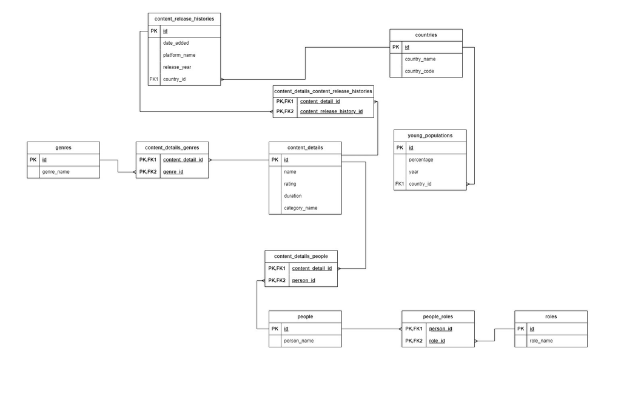

```python
Image(filename="Physical ERD_report_copy.jpg")
```

## Code to load to data in to SQL tables

## Preparing the Environment

### Setting Up Duck DB

```python
!pip install jupysql --quiet
!pip install duckdb-engine --quiet

import duckdb

class ClassDictCursor():
    def __init__(self, duckdb_con):
        self.con = duckdb_con
        self.column_names = [desc[0] for desc in self.con.description]

    def __iter__(self):
        return self

    def __next__(self):
        if (next_result := self.con.fetchone()):
            return dict(zip(self.column_names, next_result))
        else:
            raise StopIteration

%reload_ext sql
%config SqlMagic.autopandas = True
%config SqlMagic.feedback = False
%config SqlMagic.displaycon = False
%sql duckdb:///duckdb-file.db
```

```
  WARNING: The scripts ipython and ipython3 are installed in '/home/repl/.local/bin' which is not on PATH.
  Consider adding this directory to PATH or, if you prefer to suppress this warning, use --no-warn-script-location.
```

### Setting up the Fuzzy Wizzy Library

```python
!pip install fuzzywuzzy --quiet
```

## Fuzzy Matching Module

### Importing Required Libraries For Fuzzy Matching

```python
from sentence_transformers import SentenceTransformer
from fuzzywuzzy import fuzz
import csv
import pandas as pd
```

### Functions for Fuzzy Matching Module

In this section, we have created a Fuzzy Matching Module to handle similarities in the titles and avoid any repetition.

**Algorithm:**

1. Add a column to each CSV file to indicate the OTT platform it was added in.
2. Compare any 2 datasets.
3. For Netflix and Amazon, call the function 'find_similar_titles' to create a disctionary of all similar titles having a similarity ratio grater than 80.
4. Call the function 'combine_and_remove_similar_titles' to create a database of common titles containing information like date it was added to the first platform and second platform and the repeted entries are removed from the database. In simple words we are creating an external data base (stored in the array 'combined_rows') comprimsing of the fuzzy matched titles.
5. Finally, all other titles that are not similar are added.
6. Now we compare Netflix with Hulu and Netflix with Disney.
7. From the next iteration, we compare Amazon with Hulu and Amazon with Disney, and so on.
8. Finally, we create a new CSV file from this combined database (stored in an erray 'combined_rows').

```python
def add_ott_platform_column_to_csv(file_path,constant_value):
    # Read the CSV file into a pandas DataFrame
    df = pd.read_csv(file_path)
    df['OTT_platform'] = constant_value
    # Write the updated DataFrame back to a CSV file
    updated_file_path = f'{constant_value}_updated.csv'
    # Replace 'updated_file.csv' with the desired output file path
    df.to_csv(updated_file_path, index=False)

# Function to find similar titles using fuzzy matching
def find_similar_titles(dataset1, dataset2):
    similar_titles = {}
    for title1 in dataset1:
        for title2 in dataset2:
            similarity_ratio = fuzz.ratio(title1, title2)
            if similarity_ratio > 80:  # Adjust the threshold as needed
                similar_titles[title1] = title2
                break
    return similar_titles

# Read local CSV files for Netflix, Hulu, Disney, and Amazon
def read_csv(file_path):
    data = {}
    with open(file_path, newline='', encoding='utf-8') as csvfile:
        reader = csv.DictReader(csvfile)
        for row in reader:
            title = row['title']
            country = row['country']
            date_added = row['date_added']
            director = row['director']
            cast = row['cast']
            release_year = row['release_year']
            rating = row["rating"]
            duration = row["duration"]
            listed_in = row["listed_in"]
            category_type = row["type"]

            if title not in data:
                data[title] = {
                    'Country': [],
                    'Date Added':[],
                    'director':director,
                    'cast':cast,
                    'release_year':release_year,
                    'rating':rating,
                    'duration':duration,
                    'listed_in':listed_in,
                    'type' : category_type
                }
            data[title]['Country'].append(country)
            data[title]['Date Added'].append(date_added)
    return data

def remove_similar_titles(original_dataset, similar_titles):
    for title,matched_title in similar_titles.items():
        if matched_title in original_dataset:
            del original_dataset[matched_title]

def combine_and_remove_similar_titles(data1, data2, similar_titles, combined_rows, combined_titles, platform1, platform2):
    for title, matched_title in similar_titles.items():
        combined_row = {
            'title': title,
            f'country_{platform1}': ','.join(data1[title]['Country']),
            f'date_added_{platform1}': ','.join(data1[title]['Date Added']),
            f'country_{platform2}': ','.join(data2[matched_title]['Country']),
            f'date_added_{platform2}': ','.join(data2[matched_title]['Date Added']),
            'director':data1[title]['director'],
            'cast':data1[title]['cast'],
            'release_year':data1[title]['release_year'],
            'rating':data1[title]['rating'],
            'duration':data1[title]['duration'],
            'listed_in':data1[title]['listed_in'],
            'type': data1[title]['type']
            # Add similar data for other platforms as needed
        }
        combined_rows.append(combined_row)
        combined_titles.add(title)

    remove_similar_titles(data2, similar_titles)

def add_non_similar_titles(combined_rows,combined_titles,data,platform):
    for title, data in data.items():
        if title not in combined_titles:
            combined_row = {
                'title': title,
                f'country_{platform}': ','.join(data['Country']) if 'Country' in data else '',
                f'date_added_{platform}': ','.join(data['Date Added']) if 'Date Added' in data else '',
                'director':data['director'],
                'cast':data['cast'],
                'release_year':data['release_year'],
                'rating':data['rating'],
                'duration':data['duration'],
                'listed_in':data['listed_in'],
                'type': data['type']
                # Add other columns for data
            }
            combined_rows.append(combined_row)
            combined_titles.add(title)
```

### Adding a column to each CSV file to identify which platform the content belongs to

```python
add_ott_platform_column_to_csv("netflix_titles.csv","Netflix")
add_ott_platform_column_to_csv("hulu_titles.csv","Hulu")
add_ott_platform_column_to_csv("amazon_prime_titles.csv","Amazon_Prime")
add_ott_platform_column_to_csv("disney_plus_titles.csv","Disney_Plus")
```

```python
netflix_data = read_csv('Netflix_updated.csv')
hulu_data = read_csv('Hulu_updated.csv')
disney_data = read_csv('Disney_Plus_updated.csv')
amazon_data = read_csv('Amazon_Prime_updated.csv')
```

## Using Sentence Transformer and Fuzzy Wuzzy to match titles of all Over the top (OTT) Platforms and create a combined data without any duplicate title entry

```python
# Load a pre-trained sentence transformer model
model = SentenceTransformer('sentence-transformers/bert-base-nli-mean-tokens')

# Perform operations based on similar titles found
# For instance, create a combined row for each similar title with data from different platforms
combined_rows = []
combined_titles = set()

# Encode titles using the pre-trained model to get embeddings
netflix_embeddings = {title: model.encode(title) for title in netflix_data}
hulu_embeddings = {title: model.encode(title) for title in hulu_data}
disney_embeddings = {title: model.encode(title) for title in disney_data}
amazon_embeddings = {title: model.encode(title) for title in amazon_data}

# Find similar titles using fuzzy matching on embeddings
netflix_hulu_similar_titles = find_similar_titles(netflix_embeddings, hulu_embeddings)
netflix_disney_similar_titles = find_similar_titles(netflix_embeddings, disney_embeddings)
netflix_amazon_similar_titles = find_similar_titles(netflix_embeddings, amazon_embeddings)

## matching titles netflix with amazon, hulu, and disney
combine_and_remove_similar_titles(netflix_data,hulu_data,netflix_hulu_similar_titles,combined_rows, combined_titles, "netflix", "hulu")
combine_and_remove_similar_titles(netflix_data,disney_data,netflix_disney_similar_titles,combined_rows, combined_titles, "netflix", "disney")
combine_and_remove_similar_titles(netflix_data,amazon_data,netflix_amazon_similar_titles,combined_rows, combined_titles, "netflix", "amazon")

# non similar rows from netflix
add_non_similar_titles(combined_rows,combined_titles,netflix_data,"netflix")

# re_embedd as similar titles to netflix is removed from these below platforms
hulu_embeddings = {title: model.encode(title) for title in hulu_data}
disney_embeddings = {title: model.encode(title) for title in disney_data}
amazon_embeddings = {title: model.encode(title) for title in amazon_data}

# ... Repeat similar title matching for other combinations
hulu_disney_similar_titles = find_similar_titles(hulu_embeddings, disney_embeddings)
hulu_amazon_similar_titles = find_similar_titles(hulu_embeddings, amazon_embeddings)

## matching titles hulu with dinsey, and amazon
combine_and_remove_similar_titles(hulu_data,disney_data,hulu_disney_similar_titles,combined_rows, combined_titles, "hulu", "disney")
combine_and_remove_similar_titles(hulu_data,amazon_data,hulu_amazon_similar_titles,combined_rows, combined_titles, "hulu", "amazon")

add_non_similar_titles(combined_rows,combined_titles,hulu_data,"hulu")

# re_embedd as similar titles to hulu is removed from these below platforms
disney_embeddings = {title: model.encode(title) for title in disney_data}
amazon_embeddings = {title: model.encode(title) for title in amazon_data}

## ... Repeat similar title matching for other combinations
disney_amazon_similar_titles = find_similar_titles(disney_embeddings, amazon_embeddings)
## matching titles dinsey, and amazon
combine_and_remove_similar_titles(disney_data,amazon_data,disney_amazon_similar_titles,combined_rows, combined_titles, "disney", "amazon")

add_non_similar_titles(combined_rows,combined_titles,disney_data,"disney")
add_non_similar_titles(combined_rows,combined_titles,amazon_data,"amazon")
```

## Exporting the data as CSV file

Here, we are creating a combined CSV file with all the fuzzy matched titles.

```python
with open('final_combined_data.csv', 'w', newline='', encoding='utf-8') as csvfile:
        fieldnames = ['title', 'country_netflix', 'date_added_netflix', 'country_hulu', 'date_added_hulu', 'country_disney', 'date_added_disney', 'country_amazon', 'date_added_amazon','director','cast','release_year','rating','duration','listed_in','type']
        writer = csv.DictWriter(csvfile, fieldnames=fieldnames)
        writer.writeheader()
        writer.writerows(combined_rows)
```

Adding delay time for execution to facilitate the above csv file export to be reflected in datacamp workspace. This is as a precautionary step so that we wont encounter any file not found error if there is any delay in csv file export in the datacamp workspace

```python
import time

# Introducing a Delay in the code execution for 60 seconds so that final_combined_data.csv ie fuzzy matched and combined csv export from previous cell gets reflected in datacamp workspace inorder to avoid file not found error for the csv files to be used in next steps
time.sleep(60)
```

## Libraries for Database Design

```python
import datetime
import re
import csv
from IPython.display import Image # Using this library to support HTML embed
```

## Functions for the Database Design

In the next section, we have created a few commonly used functions to ensure that our code is modular and easy to reproduce. The functions below are for formatting a date, removing special characters from strings, and fuzzy matching (in the case of handling alternative country names).

```python
def formatStringDate(date_string):
    possible_formats = [
        '%d-%b-%y',  # Format: YYYY-MM-DD
        '%B %d, %Y'
        # Add more date formats as needed to cover the possible patterns
    ]

    formatted_date = None
    for date_format in possible_formats:
        try:
            parsed_date = datetime.datetime.strptime(date_string, date_format)
            formatted_date = parsed_date.strftime('%Y-%m-%d %H:%M:%S')  # Convert to desired DB format
            break  # Break the loop if a matching format is found
        except ValueError:
            continue  # Try the next format if this one fails

    return formatted_date

def formatStringDateYear(year_string):
    # Convert the year string to an integer
    year = int(year_string)

    # Create a date object with the specified year
    date_object = datetime.date(year, 1, 1)

    # Convert the date object to a string
    date_string = date_object.strftime('%Y-%m-%d')

    return date_string

def remove_special_characters(input_string):
    #replace all characters except a-z and A-Z and 0-9 (alphanumeric values) with ""
    return re.sub(r'[^a-zA-Z0-9\s]', '', input_string)

def fuzzy_match_string(string1, string2):
    partial_ratio = fuzz.partial_ratio(string1, string2)
    if partial_ratio > 99.95:
        return True
    else:
        return False
```

## Creating tables as per Physical ER diagram

In this section, we are creating all the databases or tables according to our physical ER diagram.

```python
%%sql
DROP TABLE IF EXISTS content_details;
DROP SEQUENCE IF EXISTS seq_content_details_id;
CREATE SEQUENCE seq_content_details_id START 1;
CREATE TABLE content_details (
    id INT PRIMARY KEY DEFAULT NEXTVAL('seq_content_details_id'),
    name TEXT,
    rating TEXT,
    duration TEXT,
    category_name TEXT
);


DROP TABLE IF EXISTS people;
DROP SEQUENCE IF EXISTS seq_people_id;
CREATE SEQUENCE seq_people_id START 1;
CREATE TABLE people (
    id INT PRIMARY KEY DEFAULT NEXTVAL('seq_people_id'),
    person_name TEXT
);

DROP TABLE IF EXISTS content_details_people;
CREATE TABLE content_details_people (
  content_detail_id INT,
  person_id INT
);

DROP TABLE IF EXISTS roles;
DROP SEQUENCE IF EXISTS seq_roles_id;
CREATE SEQUENCE seq_roles_id START 1;
CREATE TABLE roles (
    id INT PRIMARY KEY DEFAULT NEXTVAL('seq_roles_id'),
    role_name TEXT
);

DROP TABLE IF EXISTS people_roles;
CREATE TABLE people_roles (
  person_id INT,
  role_id INT
);

DROP TABLE IF EXISTS genres;
DROP SEQUENCE IF EXISTS seq_genres_id;
CREATE SEQUENCE seq_genres_id START 1;
CREATE TABLE genres (
    id INT PRIMARY KEY DEFAULT NEXTVAL('seq_genres_id'),
    genre_name TEXT
);

DROP TABLE IF EXISTS content_details_genres;
CREATE TABLE content_details_genres (
  content_detail_id INT,
  genre_id INT
);



DROP TABLE IF EXISTS content_release_histories;
DROP SEQUENCE IF EXISTS seq_content_release_histories_id;
CREATE SEQUENCE seq_content_release_histories_id START 1;
CREATE TABLE content_release_histories (
    id INT PRIMARY KEY DEFAULT NEXTVAL('seq_content_release_histories_id'),
    date_added date,
    release_year date,
    platform_name TEXT,
    country_id INT,
);

DROP TABLE IF EXISTS content_details_content_release_histories;
CREATE TABLE content_details_content_release_histories (
	content_detail_id INT,
	content_release_history_id INT
);

DROP TABLE IF EXISTS countries;
DROP SEQUENCE IF EXISTS seq_countries_id;
CREATE SEQUENCE seq_countries_id START 1;
CREATE TABLE countries (
    id INT PRIMARY KEY DEFAULT NEXTVAL('seq_countries_id'),
    country_name TEXT,
    country_code TEXT
);


DROP TABLE IF EXISTS young_populations;
DROP SEQUENCE IF EXISTS seq_young_populations_id;
CREATE SEQUENCE seq_young_populations_id START 1;
CREATE TABLE young_populations (
    id INT PRIMARY KEY DEFAULT NEXTVAL('seq_young_populations_id'),
    percentage INT,
    year DATE,
    country_id INT
);
```

|  | Count |
| --- | --- |

## Creating genres Table: Creating a set of genres from all the rows from combined data to have catalogue of genres and inserting into genres table

```python
with duckdb.connect('duckdb-file.db') as con:

    sql_placeholder = "INSERT INTO genres(genre_name) VALUES ($genre_name) RETURNING id"

    with open('final_combined_data.csv') as csvfile:
        myCSVReader = csv.DictReader(csvfile, delimiter=",", quotechar='"')
        unique_genre_name_set = set()

        for row in myCSVReader:
            genre_list_per_content = row['listed_in'].split(",");
            for genre in genre_list_per_content:
                genre = remove_special_characters(genre.strip())
                param_dict = {'genre_name': genre}
                if genre not in unique_genre_name_set:
                    con.execute(sql_placeholder, param_dict)
                    unique_genre_name_set.add(genre)
```

```python
%%sql
select *
from genres;
```

|  | id | genre_name |
| --- | --- | --- |
| 0 | 1 | TV Dramas |
| 1 | 2 | TV Horror |
| 2 | 3 | TV Mysteries |
| 3 | 4 | Comedies |
| 4 | 5 | Dramas |
| ... | ... | ... |
| 113 | 114 | Faith and Spirituality |
| 114 | 115 | Military and War |
| 115 | 116 | Unscripted |
| 116 | 117 | Young Adult Audience |
| 117 | 118 | Arthouse |

118 rows × 2 columns

## Creating content_details and content_details_genres Tables: Inserting all the required values from combined data into content_Details table and also insert values in content_details_genres association table

```python
with duckdb.connect('duckdb-file.db') as con:

    sql_placeholder = "INSERT INTO content_details(name,rating,duration,category_name) VALUES ($name,$rating,$duration,$category_name) RETURNING id"

    with open('final_combined_data.csv') as csvfile:
        myCSVReader = csv.DictReader(csvfile, delimiter=",", quotechar='"')

        for content in myCSVReader:
            param_dict = {'name': content['title'],
                          'rating': content['rating'],
                          'duration': content['duration'],
                          'category_name': content['type'],
                         }
            result = con.execute(sql_placeholder, param_dict).fetchone()
            content_id = result[0]

            content_genre_list = content['listed_in'].split(",")

            for genre in content_genre_list:
                genre = remove_special_characters(genre.strip())
                query = f"SELECT id FROM genres WHERE genre_name = '{genre}'"

                genre_id = con.execute(query).fetchone()[0]

                query_insert = f"INSERT INTO content_details_genres(content_detail_id, genre_id) VALUES({content_id}, {genre_id})"
                con.execute(query_insert)

            # print(f"Received {content_id}, {content['title']}, {content['rating']}, {content['duration']}, {content['type']}")
```

```python
%%sql
select *
from content_details
```

|  | id | name | rating | duration | category_name |
| --- | --- | --- | --- | --- | --- |
| 0 | 1 | Midnight Mass | TV-MA | 1 Season | TV Show |
| 1 | 2 | The Starling | PG-13 | 104 min | Movie |
| 2 | 3 | Dear White People | TV-MA | 4 Seasons | TV Show |
| 3 | 4 | Grown Ups | PG-13 | 103 min | Movie |
| 4 | 5 | He-Man and the Masters of the Universe | TV-Y7 | 1 Season | TV Show |
| ... | ... | ... | ... | ... | ... |
| 21544 | 21545 | Pride Of The Bowery | 7+ | 60 min | Movie |
| 21545 | 21546 | Planet Patrol | 13+ | 4 Seasons | TV Show |
| 21546 | 21547 | Outpost | R | 90 min | Movie |
| 21547 | 21548 | Maradona: Blessed Dream | TV-MA | 1 Season | TV Show |
| 21548 | 21549 | Harry Brown | R | 103 min | Movie |

21549 rows × 5 columns

```python
%%sql
SELECT *
FROM content_details_genres;
```

|  | content_detail_id | genre_id |
| --- | --- | --- |
| 0 | 1 | 1 |
| 1 | 1 | 2 |
| 2 | 1 | 3 |
| 3 | 2 | 4 |
| 4 | 2 | 5 |
| ... | ... | ... |
| 45238 | 21548 | 49 |
| 45239 | 21548 | 66 |
| 45240 | 21549 | 52 |
| 45241 | 21549 | 49 |
| 45242 | 21549 | 106 |

45243 rows × 2 columns

## Creating countries and young_populations Tables

## Inserting into conuntries table all the countries available from the combined data. While inserting the countries and its code we fuzzy matched using country_names_codes.csv file for all the country names in combined OTT platform data so that there is no duplicate country names and code. This provides us all the countries needed to be present in countries table and also fuzzy matching with another country names and code dataset enabled us to eliminate having alternate country name as fuzzy matching takes care of closely related countries into one country and also gets the approopriate country code

## Here we use two csv files and the country_names_codes file scan is resetted to start with 1st row in csv file using csv.seek(0) so that each row in final_combined_data.csv and the content's countries list are fuzzy matched with each of the rows in country_names_codes.csv.

```python
with duckdb.connect('duckdb-file.db') as con:
    # code to be uncommented if any error is there in this code cell
    # drop_table = '''
    # DROP TABLE IF EXISTS countries;
    # DROP SEQUENCE IF EXISTS seq_countries_id;
    # CREATE SEQUENCE seq_countries_id START 60;
    # CREATE TABLE countries (
    #     id INT PRIMARY KEY DEFAULT NEXTVAL('seq_countries_id'),
    #     country_name TEXT,
    #     country_code TEXT
    # );
    # '''
    # con.execute(drop_table);
    sql_placeholder = '''
    INSERT INTO countries(country_name, country_code) VALUES ($country_name, $country_code) RETURNING id;
    '''
    platforms = ['netflix', 'hulu', 'disney', 'amazon']
    with open('final_combined_data.csv') as csvfile1, open('country_names_codes.csv') as csvfile2:

        csv_reader_1 = csv.DictReader(csvfile1, delimiter=",", quotechar='"')
        csv_reader_2 = csv.DictReader(csvfile2, delimiter=",", quotechar='"')
        unique_country_name = set()
        countries_codes_visited={};
        for row in csv_reader_1:
            for platform in platforms:
                platform_country = row[f'country_{platform}']
                if platform_country:
                    country_list_per_content = platform_country.split(",")
                    for country in country_list_per_content:
                        country = remove_special_characters(country.strip())
                        csvfile2.seek(0)
                        if country not in countries_codes_visited:
                            for row2 in csv_reader_2:
                                country_code = row2['Alpha-3 code']
                                country_name = row2['Country']

                                if fuzzy_match_string(country, country_name):
                                    param_dict = {'country_name': country, 'country_code': country_code}
                                    if country not in unique_country_name and country:
                                        con.execute(sql_placeholder, param_dict)
                                        unique_country_name.add(country)
                                        countries_codes_visited[country] = country_code
```

```python
%%sql
select *
from countries;
```

|  | id | country_name | country_code |
| --- | --- | --- | --- |
| 0 | 1 | United States | USA |
| 1 | 2 | Canada | CAN |
| 2 | 3 | Mexico | MEX |
| 3 | 4 | United Kingdom | GBR |
| 4 | 5 | South Korea | KOR |
| ... | ... | ... | ... |
| 119 | 120 | Montenegro | MNE |
| 120 | 121 | Tunisia | TUN |
| 121 | 122 | French Polynesia | PYF |
| 122 | 123 | Tanzania | TZA |
| 123 | 124 | Monaco | MCO |

124 rows × 3 columns

## Loading values to young_populations table and also matched using the country code with country table

```python
with duckdb.connect('duckdb-file.db') as con:

    drop_table = '''
    DROP TABLE IF EXISTS young_populations;
    DROP SEQUENCE IF EXISTS seq_young_populations_id;
    CREATE SEQUENCE seq_young_populations_id START 70;
    CREATE TABLE young_populations (
        id INT PRIMARY KEY DEFAULT NEXTVAL('seq_young_populations_id'),
        percentage FLOAT,
        year DATE,
        country_id INT
    );
    '''
    con.execute(drop_table);

    sql_placeholder = "INSERT INTO young_populations(percentage,year,country_id) VALUES ($percentage,$year,$country_id) RETURNING id"
    select_country_name_id_query = "SELECT id FROM countries WHERE country_code = $country_code"
  #  query_insert = f"INSERT INTO content_details_genres(content_details_id, genre_id) VALUES({content_id}, {genre_id})"


    with open('young_populations.csv') as csvfile:
        myCSVReader = csv.DictReader(csvfile, delimiter=",", quotechar='"')

        for rows in myCSVReader:
            param_dict_select_query = {'country_code':rows['LOCATION']} ;
            country_ids = con.execute(select_country_name_id_query,param_dict_select_query).fetchone()
            if(country_ids):
                country_id = country_ids[0]
                year_string = formatStringDateYear(rows['TIME'])
                param_dict = {'percentage': rows['Value'],
                              'year': year_string,
                              'country_id': country_id,
                             }
                con.execute(sql_placeholder, param_dict)
```

```python
%%sql
SELECT * FROM young_populations
```

|  | id | percentage | year | country_id |
| --- | --- | --- | --- | --- |
| 0 | 70 | 26.604473 | 1950-01-01 | 23 |
| 1 | 71 | 27.145351 | 1951-01-01 | 23 |
| 2 | 72 | 27.601460 | 1952-01-01 | 23 |
| 3 | 73 | 28.122696 | 1953-01-01 | 23 |
| 4 | 74 | 28.590664 | 1954-01-01 | 23 |
| ... | ... | ... | ... | ... |
| 3718 | 3788 | 28.832872 | 2018-01-01 | 41 |
| 3719 | 3789 | 28.678499 | 2019-01-01 | 41 |
| 3720 | 3790 | 28.479174 | 2020-01-01 | 41 |
| 3721 | 3791 | 28.316051 | 2021-01-01 | 41 |
| 3722 | 3792 | 28.071564 | 2022-01-01 | 41 |

3723 rows × 4 columns

## Insert values into content_release_histories table and content_details_content_release_histories table -

1. Here using platformwise date added, release year each of the rows are inserted into content_release_histories as each date_added and in each country should be considered unique value. So we get the country names from the csv file and match it with countries tables and insert those relevant ids for each releases and also we get the content id from content_details_table using content name.
2. This is where fuzzy matching that was done initially really helps, now we are very sure that csv file title and the database title will have proper match and so to get the content_Detail id is much more easier. If not fuzzy matched and combine the data initially we have the fuzzy match a particular name with all of the rows in the sql and it will take lot of time to execute and also it would be error prone and time taken to test the inserted values to be accurate would be cumbersome.

```python
with duckdb.connect('duckdb-file.db') as con:
    drop_table = '''
        DROP TABLE IF EXISTS content_release_histories;
        DROP SEQUENCE IF EXISTS seq_content_release_histories_id;
        CREATE SEQUENCE seq_content_release_histories_id START 1;
        CREATE TABLE content_release_histories (
            id INT PRIMARY KEY DEFAULT NEXTVAL('seq_content_release_histories_id'),
            date_added date,
            release_year date,
            platform_name TEXT,
            country_id INT
        );
        DROP TABLE IF EXISTS content_details_content_release_histories;
        CREATE TABLE content_details_content_release_histories (
            content_detail_id INT,
            content_release_history_id INT
        );
    '''
    con.execute(drop_table)

    sql_placeholder = '''
    INSERT INTO content_release_histories (date_added, release_year, country_id,platform_name) VALUES ($date_added, $release_year, $country_id,$platform_name) RETURNING id;
    '''

    sql_content_ids_association_table = '''
    INSERT INTO content_details_content_release_histories (content_detail_id, content_release_history_id) VALUES ($content_details_id,$content_release_histories_id);
    '''
    sql_country_ids_query = '''
    SELECT id FROM countries WHERE country_name = $country_name;
    '''

    sql_content_ids_query = '''
    SELECT id FROM content_details WHERE name = $content_name;
    '''
    platforms = ['netflix', 'hulu', 'disney', 'amazon']

    with open('final_combined_data.csv') as csvfile:
        csvreader = csv.DictReader(csvfile, delimiter=",", quotechar='"')

        for row in csvreader:
             for platform in platforms:
                platform_country = row[f'country_{platform}'].strip()
                platform_date_added = row[f'date_added_{platform}'].strip()
                # print("platform_date_added:", platform_date_added)

                param_dict_content_id = {'content_name': row['title']}
                if not platform_country:
                    # print("inside if loop for null country")
                    continue
                country_list_per_content = platform_country.split(",")
                # print(country_list_per_content)
                for country in country_list_per_content:
                    # print("inside for loop")
                    country = remove_special_characters(country.strip())
                    # print(":" + country )
                    param_dict_country_id = {'country_name': country}
                    if not (platform_date_added or row['release_year']) or not country:
                        continue

                    country_id_result  = con.execute(sql_country_ids_query, param_dict_country_id).fetchone()
                    content_id_result  = con.execute(sql_content_ids_query, param_dict_content_id).fetchone()

                    if country_id_result is not None and content_id_result is not None:
                        country_id = country_id_result[0]
                        content_id = content_id_result[0]

                    date_added = platform_date_added.strip()
                    stringDate = formatStringDate(date_added) if date_added else None
                    release_year = row['release_year'].strip()
                    stringYear = formatStringDateYear(release_year) if release_year else None
                    # print("date added:", stringDate)
                    param_dict_insert = {
                        'date_added': stringDate,
                        'release_year': stringYear,
                        'country_id': country_id,
                        'platform_name' : platform
                    }

                    con.execute(sql_placeholder, param_dict_insert)
                    content_history_details_id = con.fetchone()[0]

                    param_dict_association_table ={
                        'content_details_id': content_id,
                        'content_release_histories_id': content_history_details_id
                    }

                    con.execute(sql_content_ids_association_table, param_dict_association_table)
```

```python
%%sql
SELECT *
FROM content_release_histories;
```

|  | id | date_added | release_year | platform_name | country_id |
| --- | --- | --- | --- | --- | --- |
| 0 | 1 | 2019-12-27 | 2021-01-01 | hulu | 1 |
| 1 | 2 | 2021-09-24 | 2021-01-01 | netflix | 1 |
| 2 | 3 | 2018-05-16 | 2021-01-01 | hulu | 1 |
| 3 | 4 | 2018-05-16 | 2021-01-01 | hulu | 2 |
| 4 | 5 | 2018-05-16 | 2021-01-01 | hulu | 3 |
| ... | ... | ... | ... | ... | ... |
| 14642 | 14643 | NaT | 2009-01-01 | amazon | 1 |
| 14643 | 14644 | NaT | 2008-01-01 | amazon | 1 |
| 14644 | 14645 | NaT | 2008-01-01 | amazon | 1 |
| 14645 | 14646 | NaT | 2010-01-01 | amazon | 1 |
| 14646 | 14647 | NaT | 2006-01-01 | amazon | 1 |

14647 rows × 5 columns

```python
%%sql
SELECT *
FROM content_details_content_release_histories;
```

|  | content_detail_id | content_release_history_id |
| --- | --- | --- |
| 0 | 1 | 1 |
| 1 | 2 | 2 |
| 2 | 2 | 3 |
| 3 | 2 | 4 |
| 4 | 2 | 5 |
| ... | ... | ... |
| 14642 | 21497 | 14643 |
| 14643 | 21506 | 14644 |
| 14644 | 21526 | 14645 |
| 14645 | 21528 | 14646 |
| 14646 | 21529 | 14647 |

14647 rows × 2 columns

## Creating roles Table: We have two types of roles which is director and cast, so inserted those values into roles table

```python
with duckdb.connect('duckdb-file.db') as con:
    drop_table = '''
        DROP TABLE IF EXISTS roles;
        DROP SEQUENCE IF EXISTS seq_roles_id;
        CREATE SEQUENCE seq_roles_id START 1;
        CREATE TABLE roles (
            id INT PRIMARY KEY DEFAULT NEXTVAL('seq_roles_id'),
            role_name TEXT
        );
    '''

    con.execute(drop_table)

    sql_placeholder = '''
        INSERT INTO roles (role_name) VALUES ('Director') RETURNING id;
        INSERT INTO roles (role_name) VALUES ('Cast') RETURNING id;
    '''

    con.execute(sql_placeholder)
```

```python
%%sql
SELECT *
FROM roles;
```

|  | id | role_name |
| --- | --- | --- |
| 0 | 1 | Director |
| 1 | 2 | Cast |

## Creating people and people_roles Table: Inserting into peoples table and assigning proper role id in the people_roles association table. Here we have sliced the cast list per content and added two cast people form the list as it took a long time to process huge amount cast list per content.

```python
with duckdb.connect('duckdb-file.db') as con:

    drop_table_1 = '''
        DROP TABLE IF EXISTS people;
        DROP SEQUENCE IF EXISTS seq_people_id;
        CREATE SEQUENCE seq_people_id START 20;
        CREATE TABLE people (
            id INT PRIMARY KEY DEFAULT NEXTVAL('seq_people_id'),
            person_name TEXT
        );
    '''

    drop_table_2 = '''
        DROP TABLE IF EXISTS people_roles;
        CREATE TABLE people_roles (
            person_id INT,
            role_id INT
        );
    '''
    con.execute(drop_table_1)
    con.execute(drop_table_2)

    sql_placeholder = "INSERT INTO people(person_name) VALUES ($person_name) RETURNING id"

    with open('netflix_titles.csv') as csvfile:
        myCSVReader = csv.DictReader(csvfile, delimiter=",", quotechar='"')

        for content in myCSVReader:
            # print("inside for loop")

            director_list = content['director'].split(",")
            cast_list = content['cast'].split(",")[:2]

            for director in director_list:
                if not director:
                    continue
                # print("inside director_list")
                director = remove_special_characters(director.strip())
                param_dict = {'person_name': director}
                result = con.execute(sql_placeholder, param_dict).fetchone()
                people_id = result[0]

                # query = f"SELECT id FROM roles WHERE role_name = 'Director'"
                # role_id = con.execute(query).fetchone()[0]

                query_insert = f"INSERT INTO people_roles(person_id, role_id) VALUES({people_id}, 1)"
                con.execute(query_insert)

            for cast in cast_list:
                if not cast:
                    continue
                # print("inside cast_list")
                cast = remove_special_characters(cast.strip())
                param_dict = {'person_name': cast}
                result = con.execute(sql_placeholder, param_dict).fetchone()
                people_id = result[0]

                # query = f"SELECT id FROM roles WHERE role_name = 'Cast'"
                # role_id = con.execute(query).fetchone()[0]

                query_insert = f"INSERT INTO people_roles(person_id, role_id) VALUES({people_id}, 2)"
                con.execute(query_insert)
                # print(f"Received {content_id}, {content['title']}, {content['rating']}, {content['duration']}, {content['type']}")
```

```python
%%sql
SELECT *
FROM people
```

|  | id | person_name |
| --- | --- | --- |
| 0 | 20 | Kirsten Johnson |
| 1 | 21 | Ama Qamata |
| 2 | 22 | Khosi Ngema |
| 3 | 23 | Julien Leclercq |
| 4 | 24 | Sami Bouajila |
| ... | ... | ... |
| 22056 | 22076 | Tim Allen |
| 22057 | 22077 | Courteney Cox |
| 22058 | 22078 | Mozez Singh |
| 22059 | 22079 | Vicky Kaushal |
| 22060 | 22080 | SarahJane Dias |

22061 rows × 2 columns

```python
%%sql
SELECT *
FROM people_roles
```

|  | person_id | role_id |
| --- | --- | --- |
| 0 | 20 | 1 |
| 1 | 21 | 2 |
| 2 | 22 | 2 |
| 3 | 23 | 1 |
| 4 | 24 | 2 |
| ... | ... | ... |
| 22056 | 22076 | 2 |
| 22057 | 22077 | 2 |
| 22058 | 22078 | 1 |
| 22059 | 22079 | 2 |
| 22060 | 22080 | 2 |

22061 rows × 2 columns

## Creating a association between content_details and people involved in it using association table content_details_people. Here we have taken the director and cast separately and handled them for insertion into the table

```python
with duckdb.connect('duckdb-file.db') as con:

    drop_table = '''
        DROP TABLE IF EXISTS content_details_people;
        CREATE TABLE content_details_people (
          content_detail_id INT,
          person_id INT
        );
    '''

    con.execute(drop_table)

    sql_placeholder = "INSERT INTO content_details_people(content_detail_id, person_id) VALUES ($content_details_id, $people_id)"

    with open('final_combined_data.csv') as csvfile:
        myCSVReader = csv.DictReader(csvfile, delimiter=",", quotechar='"')

        for content in myCSVReader:
            # print("inside for loop")

            # title = remove_special_characters(content['title'].strip())
            title = content['title']
            # query = f"SELECT id FROM content_details WHERE name = '{title}'"
            query = "SELECT id FROM content_details WHERE name = ?"
            content_details_id_result = con.execute(query, (title,)).fetchone()
            # content_details_id_result = con.execute(query).fetchone()
            if content_details_id_result:
                content_details_id = content_details_id_result[0]
            else:
                continue

            director_list = content['director'].split(",")
            cast_list = content['cast'].split(",")

            for director in director_list:
                # print("inside director_list")
                director = remove_special_characters(director.strip())


                query = f"SELECT id FROM people WHERE person_name = '{director}'"
                people_id_result = con.execute(query).fetchone()
                if people_id_result:
                    people_id = people_id_result[0]
                else:
                    continue

                param_dict = {'content_details_id': content_details_id,
                              'people_id': people_id
                             }

                con.execute(sql_placeholder, param_dict)

            for cast in cast_list:
                # print("inside cast_list")
                cast = remove_special_characters(cast.strip())

                query = f"SELECT id FROM people WHERE person_name = '{cast}'"
                people_id_result = con.execute(query).fetchone()
                if people_id_result:
                    people_id = people_id_result[0]
                else:
                    continue
                param_dict = {'content_details_id': content_details_id,
                              'people_id': people_id
                             }
                con.execute(sql_placeholder, param_dict)
```

```python
%%sql
SELECT *
FROM content_details_people
```

|  | content_detail_id | person_id |
| --- | --- | --- |
| 0 | 1 | 28 |
| 1 | 1 | 29 |
| 2 | 1 | 30 |
| 3 | 1 | 19164 |
| 4 | 1 | 3682 |
| ... | ... | ... |
| 43927 | 21542 | 3747 |
| 43928 | 21544 | 1472 |
| 43929 | 21547 | 21232 |
| 43930 | 21547 | 17877 |
| 43931 | 21549 | 13995 |

43932 rows × 2 columns

## Querying

Below sample example using sql query to fetch number movies and tv shows that got added in a particular year,particular platform and particular country in comparison with young population percentage. Similar to this we will export the data into csv including all countries, young populations percentage in particular year, and the number of movies and tv shows added in each platform.

```python
%%sql
-- Query for analysis 1 - Through the years, Different countries and its number of tv and movie shows based on each ott platform
SELECT
    C.id as countryId,
    LOWER(TRIM(C.country_name)) AS country_name,
    EXTRACT(YEAR FROM CRH.date_added) AS release_year,
    LOWER(TRIM(CRH.platform_name)) AS ott_platform_name,
    LOWER(TRIM(CD.category_name)) AS category_name,
    COUNT(*) AS content_count,
    YP.percentage AS young_population_percentage,

FROM
    content_details CD
JOIN
    content_details_content_release_histories CDCH ON CD.id = CDCH.content_detail_id
JOIN
    content_release_histories CRH ON CDCH.content_release_history_id = CRH.id
JOIN
    countries C ON CRH.country_id = C.id
JOIN
    young_populations YP ON EXTRACT(YEAR FROM CRH.date_added) = EXTRACT(YEAR FROM YP.year) AND C.id = YP.country_id
GROUP BY
    LOWER(TRIM(C.country_name)), EXTRACT(YEAR FROM CRH.date_added), LOWER(TRIM(CRH.platform_name)), LOWER(TRIM(CD.category_name)), YP.percentage, countryId
ORDER BY
    LOWER(TRIM(C.country_name)), release_year, LOWER(TRIM(CD.category_name));
```

|  | countryId | country_name | release_year | ott_platform_name | category_name | content_count | young_population_percentage |
| --- | --- | --- | --- | --- | --- | --- | --- |
| 0 | 44 | argentina | 2016 | netflix | movie | 3 | 24.977850 |
| 1 | 44 | argentina | 2017 | netflix | movie | 15 | 24.819241 |
| 2 | 44 | argentina | 2017 | netflix | tv show | 1 | 24.819241 |
| 3 | 44 | argentina | 2018 | netflix | movie | 24 | 24.662531 |
| 4 | 44 | argentina | 2018 | hulu | movie | 1 | 24.662531 |
| ... | ... | ... | ... | ... | ... | ... | ... |
| 772 | 1 | united states | 2021 | amazon | movie | 7 | 18.049019 |
| 773 | 1 | united states | 2021 | hulu | tv show | 146 | 18.049019 |
| 774 | 1 | united states | 2021 | netflix | tv show | 179 | 18.049019 |
| 775 | 1 | united states | 2021 | disney | tv show | 75 | 18.049019 |
| 776 | 1 | united states | 2021 | amazon | tv show | 7 | 18.049019 |

777 rows × 7 columns

```python
%%sql
--- Young population percentage countrywise each year through the years
SELECT
    LOWER(TRIM(C.country_name)) AS country_name,
    C.id AS country_id,
    EXTRACT(YEAR FROM YP.year) AS release_year,
    YP.percentage AS young_population_percentage
FROM
    young_populations YP
JOIN
    countries C ON YP.country_id = C.id
ORDER BY
    LOWER(TRIM(C.country_name)), release_year;
```

|  | country_name | country_id | release_year | young_population_percentage |
| --- | --- | --- | --- | --- |
| 0 | argentina | 44 | 1950 | 30.526678 |
| 1 | argentina | 44 | 1951 | 30.581141 |
| 2 | argentina | 44 | 1952 | 30.632484 |
| 3 | argentina | 44 | 1953 | 30.680746 |
| 4 | argentina | 44 | 1954 | 30.725904 |
| ... | ... | ... | ... | ... |
| 3718 | united states | 1 | 2018 | 18.626747 |
| 3719 | united states | 1 | 2019 | 18.461046 |
| 3720 | united states | 1 | 2020 | 18.276989 |
| 3721 | united states | 1 | 2021 | 18.049019 |
| 3722 | united states | 1 | 2022 | 17.833666 |

3723 rows × 4 columns

## Export file for Analysis - 1

### Query to understand the relationship between shorter format content ( Movies) and longer format content (TV shows) across OTT platforms and younger population percentage in different countries through the years.

```python
# Connect to the DuckDB database
con = duckdb.connect('duckdb-file.db')

# Execute the SQL query
query = """
SELECT
    C.id as countryId,
    LOWER(TRIM(C.country_name)) AS country_name,
    EXTRACT(YEAR FROM CRH.date_added) AS release_year,
    LOWER(TRIM(CRH.platform_name)) AS ott_platform_name,
    LOWER(TRIM(CD.category_name)) AS category_name,
    COUNT(*) AS content_count,
    YP.percentage AS young_population_percentage,

FROM
    content_details CD
JOIN
    content_details_content_release_histories CDCH ON CD.id = CDCH.content_detail_id
JOIN
    content_release_histories CRH ON CDCH.content_release_history_id = CRH.id
JOIN
    countries C ON CRH.country_id = C.id
JOIN
    young_populations YP ON EXTRACT(YEAR FROM CRH.date_added) = EXTRACT(YEAR FROM YP.year) AND C.id = YP.country_id
GROUP BY
    LOWER(TRIM(C.country_name)), EXTRACT(YEAR FROM CRH.date_added), LOWER(TRIM(CRH.platform_name)), LOWER(TRIM(CD.category_name)), YP.percentage, countryId
ORDER BY
    LOWER(TRIM(C.country_name)), release_year, LOWER(TRIM(CD.category_name));
"""

# Execute the query and fetch all results
result = con.execute(query).fetchall()

# Write results to a CSV file
with open('Analysis_1.csv', 'w', newline='') as f:
    writer = csv.writer(f)
    # Write header row
    writer.writerow(['Country_id','Country', 'Release_Year', 'OTT_Platform', 'Category', 'Content_Count', 'Young_Population_Percentage'])
    # Write each row of the result to the CSV file
    for row in result:
        writer.writerow(row)
```

```python
# Connect to the DuckDB database
con = duckdb.connect('duckdb-file.db')

# Execute the SQL query to fetch young population percentage, year, country name, and ID
query = """
SELECT
    LOWER(TRIM(C.country_name)) AS country_name,
    C.id AS country_id,
    EXTRACT(YEAR FROM YP.year) AS release_year,
    YP.percentage AS young_population_percentage
FROM
    young_populations YP
JOIN
    countries C ON YP.country_id = C.id
ORDER BY
    LOWER(TRIM(C.country_name)), release_year;
"""

# Execute the query and fetch all results
result = con.execute(query).fetchall()

# Write the result to a CSV file
with open('young_pop_year_country_tableau.csv', 'w', newline='', encoding='utf-8') as f:
    writer = csv.writer(f)
    # Write header row
    writer.writerow(['Country', 'Country_ID', 'Release_Year', 'Young_Population_Percentage'])
    # Write each row of the result to the CSV file
    for row in result:
        writer.writerow([row[0], row[1], row[2], row[3]])
```

## Export file for Analysis - 2

### Query to understand the relationship between genres and young population percentage for a country. Does the young population percentage play a role in popularizing certain TV Show/Movie genres?

```python
%%sql
SELECT  c.country_name,
        EXTRACT(YEAR FROM hist.date_added) AS year,
        yp.percentage,
        g.genre_name,
        COUNT(*) AS number_of_content_in_genre,
        hist.platform_name
FROM content_details AS cd
JOIN content_details_content_release_histories AS cdcrh ON cd.id = cdcrh.content_detail_id
JOIN content_release_histories AS hist ON cdcrh.content_release_history_id = hist.id
JOIN countries AS c ON hist.country_id = c.id
JOIN young_populations AS yp ON c.id = yp.country_id
JOIN content_details_genres AS cdg ON cd.id = cdg.content_detail_id
JOIN genres AS g ON cdg.genre_id = g.id
GROUP BY    c.country_name,
            EXTRACT(YEAR FROM hist.date_added),
            EXTRACT(YEAR FROM yp.year),
            yp.percentage,
            g.genre_name,
            hist.platform_name
HAVING EXTRACT(YEAR FROM hist.date_added) = EXTRACT(YEAR FROM yp.year)
ORDER BY country_name, year
```

|  | country_name | year | percentage | genre_name | number_of_content_in_genre | platform_name |
| --- | --- | --- | --- | --- | --- | --- |
| 0 | Argentina | 2016 | 24.977850 | Dramas | 1 | netflix |
| 1 | Argentina | 2016 | 24.977850 | Comedies | 1 | netflix |
| 2 | Argentina | 2016 | 24.977850 | Sports Movies | 1 | netflix |
| 3 | Argentina | 2016 | 24.977850 | Action Adventure | 1 | netflix |
| 4 | Argentina | 2016 | 24.977850 | International Movies | 3 | netflix |
| ... | ... | ... | ... | ... | ... | ... |
| 5118 | United States | 2021 | 18.049019 | International TV Shows | 5 | hulu |
| 5119 | United States | 2021 | 18.049019 | Science Fiction | 8 | hulu |
| 5120 | United States | 2021 | 18.049019 | SpanishLanguage TV Shows | 5 | netflix |
| 5121 | United States | 2021 | 18.049019 | Classic Movies | 22 | netflix |
| 5122 | United States | 2021 | 18.049019 | Musical | 3 | disney |

5123 rows × 6 columns

```python
# converting above query to a csv file for analysis

# Connect to the DuckDB database
con = duckdb.connect('duckdb-file.db')

# Query to analyse the relationship that genre plays in different platforms, in countries having different population percentages, across years.
query = """
SELECT  c.country_name,
        EXTRACT(YEAR FROM hist.date_added) AS year,
        yp.percentage,
        g.genre_name,
        COUNT(*) AS number_of_content_in_genre,
        hist.platform_name
FROM content_details AS cd
JOIN content_details_content_release_histories AS cdcrh ON cd.id = cdcrh.content_detail_id
JOIN content_release_histories AS hist ON cdcrh.content_release_history_id = hist.id
JOIN countries AS c ON hist.country_id = c.id
JOIN young_populations AS yp ON c.id = yp.country_id
JOIN content_details_genres AS cdg ON cd.id = cdg.content_detail_id
JOIN genres AS g ON cdg.genre_id = g.id
GROUP BY    c.country_name,
            EXTRACT(YEAR FROM hist.date_added),
            EXTRACT(YEAR FROM yp.year),
            yp.percentage,
            g.genre_name,
            hist.platform_name
HAVING EXTRACT(YEAR FROM hist.date_added) = EXTRACT(YEAR FROM yp.year)
ORDER BY country_name, year
"""

# Execute the query and fetch all results
result = con.execute(query).fetchall()

# Write the result to a CSV file
with open('genre_analysis.csv', 'w', newline='', encoding='utf-8') as f:
    writer = csv.writer(f)
    # Write header row
    writer.writerow(['Country', 'Year', 'Young_Population_Percentage', 'Genre', 'Number_of_Content_of_Genre_in_Year', 'Platform_name'])
    # Write each row of the result to the CSV file
    for row in result:
        writer.writerow([row[0], row[1], row[2], row[3], row[4], row[5]])
```

### Analysis - 1

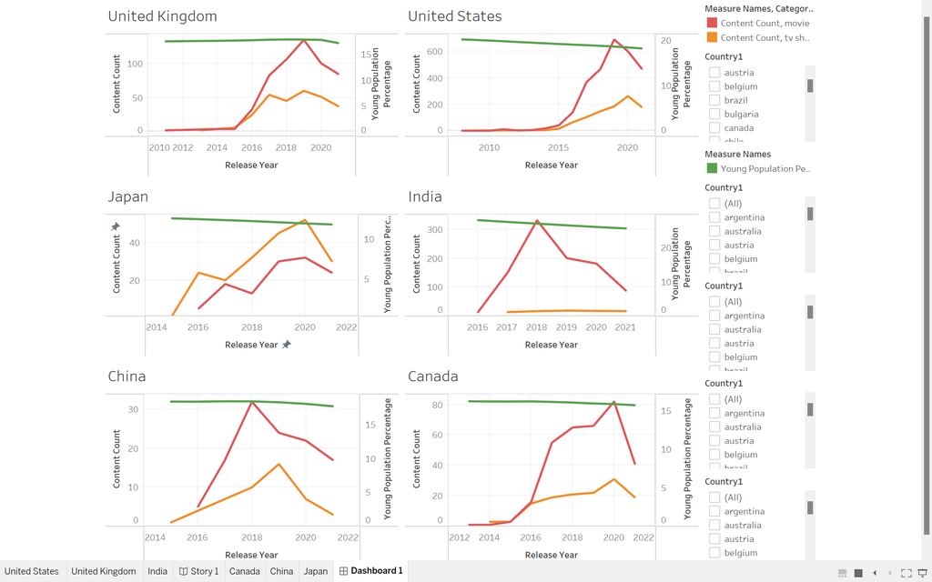

```python
Image(filename="Dashboard__countries_young_pop_tv_movies.png")
```

### Analysis - 2

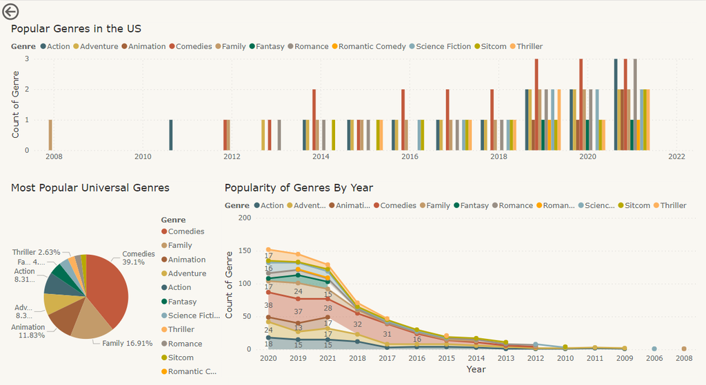

```python
Image(filename="Analysis Genres.png")
```

1. The topmost graph in the dashboard shows the various genres in the United States that achived maximum popularity. We can see see that the genre 'Comedies' has earned significant popularity in the US and has been one of the most popular genres since 2014.
2. The pie chart gives us a universal understanding of the popularity of genres. Even globally, 'Comedies' is a popular genre followed by 'Family'.
3. Finally, in the bottom right, we get an understanding of the popularity of genres by year.

## Coding through the Challenge

The primary challenge and noteworthy aspect of our project revolved around the implementation of the **Fuzzy Matching Module**. The rationale behind this step was twofold:

1. **Preventing Duplicate Entries:** Our goal was to avoid any instances of duplicate entries, such as distinguishing between "The Little Red Riding Hood" and "Little Red Riding Hood." This measure also facilitated the elimination of duplicate entries across various OTT platforms.
2. **Handling Alternate Country Names:** We aimed to address the issue of alternate country names, ensuring that distinctions like "The United States of America" and "United States of America" did not result in separate country entries.

To address these challenges, we initially employed the **Fuzzy Wuzzy library**. However, given the extensive nature of our dataset, with over 8000 rows in each content CSV file, the computation process **took more than 7 hours**. This prolonged duration was attributed to the algorithm meticulously examining each word of every title, conducting a word-by-word comparison against a pool of over 32000 words.

Looking ahead, we envision further improvements by incorporating advanced **natural language processing algorithms** in our future endeavors.

## Tools for Analysis and its learning curve

We explored course materials from youtube and there were lot of videos. We followed up on a youtube channel called Alex the Data Analyst where he teaches overall data analyst track course, we learnt the topics on Tableau and Power BI. It was introductory course on these tools. The topics that we learnt really helped us with coming with above analysis.